# Stat 579 - Homework #5 - Section B

10/1/2019

## Behavioral Risk Factor Surveillance System - Again

We are again looking at the data from the Behavioral Risk Factor Surveillance System (BRFSS).

```r
url <- "https://raw.githubusercontent.com/Stat579-at-ISU/stat579-at-isu.github.io/master/homework/data/brfss-iowa-2018.csv"
```

The following code reads the data into your R session:

```r
iowa <- read.csv(url)
library(tidyverse)
```

| HEIGHT3 value | Interpretation |
| --- | --- |
| 200 - 711 | Height (ft/inches), i.e. 410 is 4 feet, 10 inches |
| 7777 | Don’t know/Not sure |
| 9000 - 9998 | Height (meters/centimeters), where the first 9 indicates that the measurement was metric, 9165 is 1 meter 65 cm |
| 9999 | Refused |
| BLANK | Not asked or Missing |

The overall goal is to introduce a new variable `height` that corresponds to reported height in centimeters [cm].

3. Sketch out a way to derive a new variable `height` that represents the values in `HEIGHT3` in centimeters and properly encodes any unavailable information as missing values (`NA`). Implement your transformation. For your convenience: 1 ft equals 30.48 cm, 1 inch equals 2.54 cm. 1 m equals 100 cm.

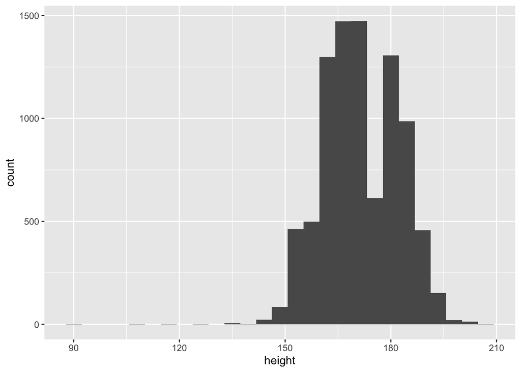

```r
iowa$height<- iowa$HEIGHT3
iowa<-iowa%>% mutate(height = replace(height, height %in% c(7777,9999),NA))
iowa<-iowa%>% mutate(height = ifelse(height>9000, (height-9000), height))
iowa<-iowa%>% mutate(height = ifelse(height %in% (200:711), (((height%/%100)*30.48) +((height%%100)*2.54)), height))
iowa%>%ggplot(aes(x=height))+geom_histogram(binwidth=4.5)
```

```r
summary(iowa$height)
```

```
##    Min. 1st Qu.  Median    Mean 3rd Qu.    Max.    NA's
##   91.44  162.56  170.18  171.23  177.80  208.28     252
```

#For this problem, I like to take it one step at a time. Much easier for me to understand. I first replaced the 7777 and 9999 values and then used ifelse statement for the values >9000 and another ifelse statement for values that were within 200:711. I think the graph turned out nice. We still dont know the differences between males/females in this histogram but you can see 2 distinct peaks which may suggest genders. This observation could also just be due to the bandwidth that I set. Be cautious of that as well - mainly just a note for myself when I look back at this assignment for when studying for the midterm!

4. How many missing values does the variable `height` have?

```r
summary(iowa$height)
```

```
##    Min. 1st Qu.  Median    Mean 3rd Qu.    Max.    NA's
##   91.44  162.56  170.18  171.23  177.80  208.28     252
```

#There are a total of 252 NA’s or “missing values”.

5. What is the average height among respondents of the survey? among men? among women? Does the result make sense? Comment.

```r
summary(iowa$height)
```

```
##    Min. 1st Qu.  Median    Mean 3rd Qu.    Max.    NA's
##   91.44  162.56  170.18  171.23  177.80  208.28     252
```

```r
height_male = iowa%>%
  filter(SEX1==1)
summary(height_male$height)
```

```
##    Min. 1st Qu.  Median    Mean 3rd Qu.    Max.    NA's
##   91.44  172.72  177.80  178.82  182.88  208.28     100
```

```r
height_female = iowa%>%
  filter(SEX1==2)
summary(height_female$height)
```

```
##    Min. 1st Qu.  Median    Mean 3rd Qu.    Max.    NA's
##   127.0   160.0   165.1   164.3   170.2   203.2     146
```

#The mean average height among the respondents of the survey is: 171.23 cm. #Among males the mean average height is: 178.82 cm. #Among females the mean average height is: 164.3 cm.

#These results are to be expected. We know from the last homework, as well as gender studies, that males are on average taller than females. The data only confirms this. The only surprising point is the minimum height for men is lower than women. But that is why we use means and not minimums in statistics! Looking closer at the heights specifically, these heights do not look deciving and should be okay to use :)